# árvore

```r
data = read.csv("data/titanic.csv")

data$Survived = as.factor(data$Survived)
data$Survived = relevel(data$Survived, ref="N")

data$Pclass = as.factor(data$Pclass)
data$Sex = as.factor(data$Sex)
data$Embarked = as.factor(data$Embarked)
```

Cálculo da impureza com Gini para o nó raiz:

```r
tab = table(data$Survived) # Y=549 N=342

pY = tab[1]/nrow(data)
pN = tab[2]/nrow(data)

gini_raiz = 1 - (pY^2 + pN^2)
gini_raiz
```

```
##        N
## 0.473013
```

Cálculo da impureza com Gini para o nó da variável sexo:

```r
male = data[data$Sex == 'male',]
female = data[data$Sex == 'female',]

# male
tab = table(male$Survived) # Y=549 N=342
pY = tab[1]/nrow(male)
pN = tab[2]/nrow(male)
gini_male = 1 - (pY^2 + pN^2)

# female
tab = table(female$Survived) # Y=549 N=342
pY = tab[1]/nrow(female)
pN = tab[2]/nrow(female)
gini_female = 1 - (pY^2 + pN^2)

# média ponderada do Gini

gini_sexo = (gini_male*nrow(male) + gini_female*nrow(female))/nrow(data)
gini_sexo
```

```
##        N
## 0.333365
```

Teríamos que calcular o Gini para cada variável e então escolher a quebra na variável de menor Gini (impureza).

O Gini varia de 0 até 0,5, sendo zero a impureza minima (overfitting, acertamos tudo) e 0.5 erramos tudo.

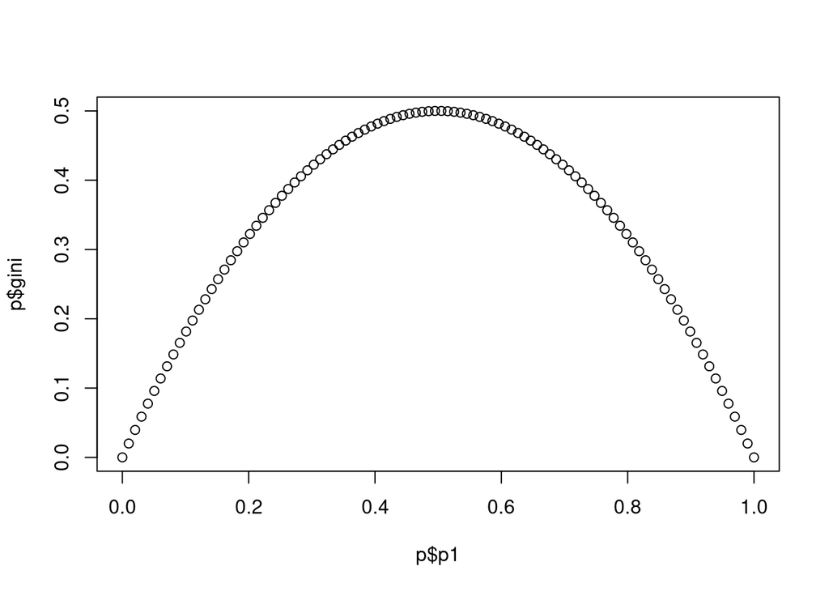

```r
p = data.frame(p1 = seq(0,1, length=100))
p$p2 = 1- p$p1
p$gini = 1 - (p$p1^2 + p$p2^2)
plot(p$p1, p$gini)
```

A entropia é um parâmetro parecido como o Gini

Descritiva:

```r
library(Rmisc)
data$survived <- as.integer(data$Survived=="Y")
data_summary_sex = summarySE(data, measurevar="survived", groupvars=c("Sex"))
data_summary_sex
```

| Sex | N | survived | sd | se | ci |
| --- | --- | --- | --- | --- | --- |
| female | 314 | 0.7420382 | 0.4382112 | 0.02472969 | 0.04865744 |
| male | 577 | 0.1889081 | 0.3917753 | 0.01630982 | 0.03203397 |

Por sexo:

```r
library(tidyverse)
```

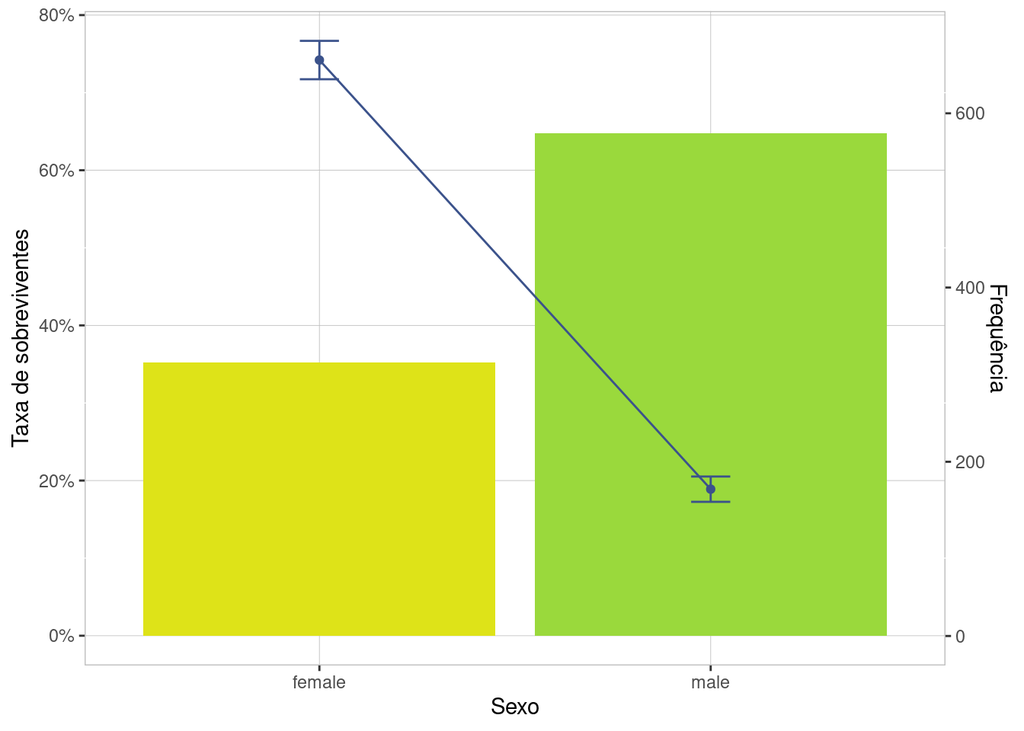

```r
 ggplot(data_summary_sex) +
   geom_bar(aes(x=Sex, fill=as.factor(Sex), weight = N/nrow(data),)) +
    geom_errorbar(aes(x=Sex, y=survived, ymin=survived-se, ymax=survived+se, colour='1'), width=.1) +

    geom_point(aes(x=Sex, y=survived, colour='1', group='1')) +
    geom_line(aes(x=Sex, y=survived, colour='1', group='1')) +

    scale_color_viridis_d(direction = -1, begin=0, end=.25) +
    scale_fill_viridis_d(direction = -1, begin=.85, end=.95) +

    theme(panel.background = element_rect(fill = "white", colour = "grey", linetype = "solid"),
          panel.grid.major = element_line(size = 0.15, linetype = 'solid', colour = "grey")) +

    theme(legend.position = "none") +
    xlab("Sexo") +
    ylab("Taxa de sobreviventes") +
    scale_y_continuous(sec.axis = sec_axis(~ . * nrow(data) , name = "Frequência"), labels = scales::percent)
```

Por idade:

```r
library(Rmisc)
library(tidyverse)
library(gtools)

data$quant_idade <- quantcut(data$Age, 5)
data_summary_idade = summarySE(data, measurevar="survived", groupvars=c("quant_idade"))
data_summary_idade
```

| quant_idade | N | survived | sd | se | ci |
| --- | --- | --- | --- | --- | --- |
| [0.42,20] | 179 | 0.4581006 | 0.4996389 | 0.03734477 | 0.07369545 |
| (20,28] | 183 | 0.3606557 | 0.4815082 | 0.03559411 | 0.07023017 |
| (28,29.7] | 199 | 0.3015075 | 0.4600700 | 0.03261350 | 0.06431438 |
| (29.7,38] | 153 | 0.4444444 | 0.4985359 | 0.04030424 | 0.07962883 |
| (38,80] | 177 | 0.3728814 | 0.4849428 | 0.03645053 | 0.07193638 |

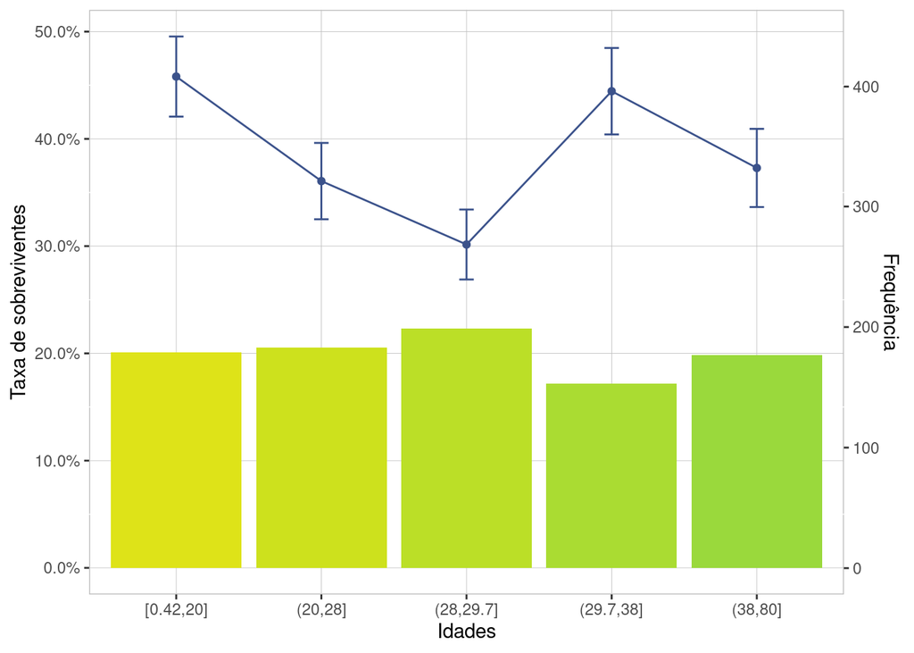

```r
ggplot(data_summary_idade) +
  geom_bar(aes(x=quant_idade, fill=as.factor(quant_idade), weight = N/nrow(data),)) +
  geom_errorbar(aes(x=quant_idade, y=survived, ymin=survived-se, ymax=survived+se, colour='1'), width=.1) +

  geom_point(aes(x=quant_idade, y=survived, colour='1', group='1')) +
  geom_line(aes(x=quant_idade, y=survived, colour='1', group='1')) +

  scale_color_viridis_d(direction = -1, begin=0, end=.25) +
  scale_fill_viridis_d(direction = -1, begin=.85, end=.95) +

  theme(panel.background = element_rect(fill = "white", colour = "grey", linetype = "solid"),
        panel.grid.major = element_line(size = 0.15, linetype = 'solid', colour = "grey")) +

  theme(legend.position = "none") +
  xlab("Idades") +
  ylab("Taxa de sobreviventes") +
  scale_y_continuous(sec.axis = sec_axis(~ . * nrow(data) , name = "Frequência"), labels = scales::percent)
```

árvore:

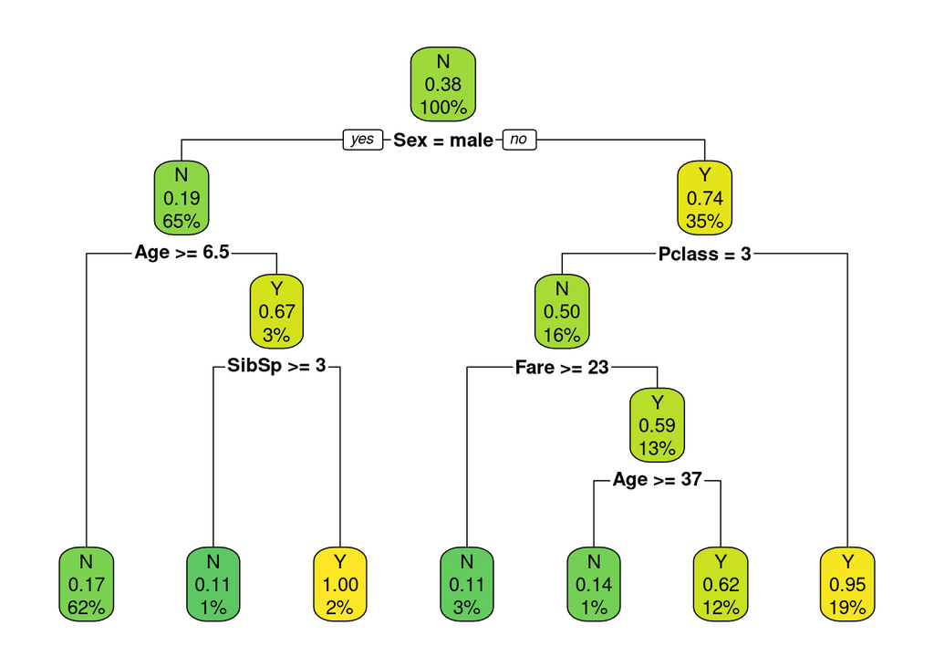

```r
library(rpart)
arvore <- rpart(Survived ~ Pclass + Sex + Age + SibSp + Parch + Fare + Embarked,
                data=data,
                parms = list(split = 'gini'),
                method='class'
)
paleta = scales::viridis_pal(begin=.75, end=1)(20)
rpart.plot::rpart.plot(arvore, box.palette = paleta)
```

- probabilidade de sobrevivência global: 38%
- probabilidade de sobrevivência de homens: 19%
- probabilidade de sobrevivência de homens com menos de 6,5 anos: 67%

## dividindo a base em treino e teste

```r
set.seed(123)
treino_bool <- stats::runif(dim(data)[1])>.25

treino <- data[treino_bool,]
teste  <- data[!treino_bool,]
```

árvove “livre” permite uma obsevação nos nós ou folhas e tem custo cp zero (permite overfitting):

```r
arvore <- rpart(Survived ~ Pclass + Sex + Age + SibSp + Parch + Fare + Embarked,
                data=treino,
                parms = list(split = 'gini'),
                method='class',
                xval=5,
                control = rpart.control(cp = 0, minsplit = 1, maxdepth = 30)
)
arvore$variable.importance
```

```
##        Age        Sex       Fare     Pclass      SibSp      Parch   Embarked
## 104.230489  91.582510  90.285115  40.449210  22.546052  22.082042   9.888616
```

predição:

```r
library(caret)
previsto = stats::predict(arvore, teste)

previsto = as.data.frame(previsto)
teste = cbind(teste,previsto)

previsto$SurvivedPredicted = "N"
previsto[previsto[,2] > 0.5,]$SurvivedPredicted = "Y"

teste = cbind(teste,SurvivedPredicted = previsto$SurvivedPredicted)
teste$SurvivedPredicted = as.factor(teste$SurvivedPredicted)
teste$SurvivedPredicted = relevel(teste$SurvivedPredicted , ref="N")

confusionMatrix(teste$SurvivedPredicted, teste$Survived, positive="N")
```

```
## Confusion Matrix and Statistics
##
##           Reference
## Prediction   N   Y
##          N 113  27
##          Y  17  65
##
##                Accuracy : 0.8018
##                  95% CI : (0.7432, 0.8521)
##     No Information Rate : 0.5856
##     P-Value [Acc > NIR] : 6.46e-12
##
##                   Kappa : 0.585
##
##  Mcnemar's Test P-Value : 0.1748
##
##             Sensitivity : 0.8692
##             Specificity : 0.7065
##          Pos Pred Value : 0.8071
##          Neg Pred Value : 0.7927
##              Prevalence : 0.5856
##          Detection Rate : 0.5090
##    Detection Prevalence : 0.6306
##       Balanced Accuracy : 0.7879
##
##        'Positive' Class : N
##
```

ROC:

```r
library(caret)
rocdata = data.frame(obs=teste$Survived,
                     pred=teste$SurvivedPredicted,
                     Y = teste$Y,
                     N = teste$N)

twoClassSummary(rocdata, lev=levels(rocdata$obs))
```

```
##       ROC      Sens      Spec
## 0.7736622 0.8692308 0.7065217
```

Curva ROC:

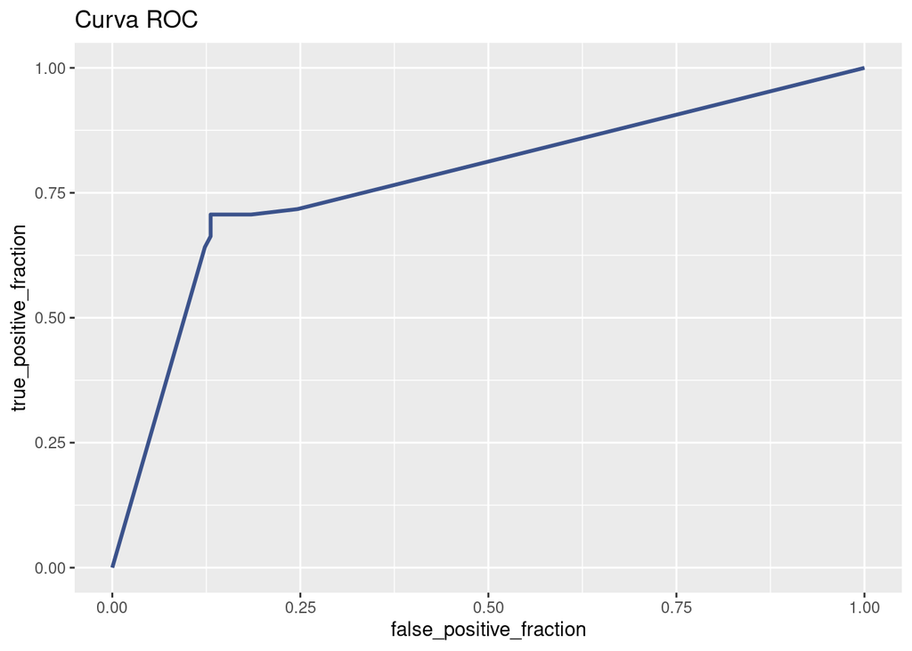

```r
library(plotROC)
ggplot(rocdata, aes(d = obs, m = Y, colour='a')) +
  plotROC::geom_roc(n.cuts = 0) +
  scale_color_viridis_d(direction = -1, begin=0, end=.25) +
  theme(legend.position = "none") +
  ggtitle("Curva ROC")
```

## pós-poda (Grid Search)

Dividimos a base de treino em k pedaços (k-fold) e recursivamente fixando um valor de cp testamos um pedaço como sendo validação e os demais k-1 como treino. Todos pedaços k são considerados como validação em algum momento e depois fazemos a média de uma métrica de desempenho, como por exemplo a acurácia. Testamos esse procedimento para diversos CP e procuramos o menor:

```r
poda = rpart::printcp(arvore)
```

```
##
## Classification tree:
## rpart(formula = Survived ~ Pclass + Sex + Age + SibSp + Parch +
##     Fare + Embarked, data = treino, method = "class", parms = list(split = "gini"),
##     control = rpart.control(cp = 0, minsplit = 1, maxdepth = 30),
##     xval = 5)
##
## Variables actually used in tree construction:
## [1] Age      Embarked Fare     Parch    Pclass   Sex      SibSp
##
## Root node error: 250/669 = 0.37369
##
## n= 669
##
##           CP nsplit rel error xerror     xstd
## 1  0.4320000      0     1.000  1.000 0.050052
## 2  0.0320000      1     0.568  0.568 0.042305
## 3  0.0300000      2     0.536  0.592 0.042943
## 4  0.0200000      4     0.476  0.572 0.042414
## 5  0.0180000      5     0.456  0.528 0.041174
## 6  0.0120000      7     0.420  0.536 0.041407
## 7  0.0080000     10     0.384  0.500 0.040328
## 8  0.0040000     16     0.332  0.488 0.039950
## 9  0.0026667     41     0.224  0.456 0.038900
## 10 0.0020000     44     0.216  0.452 0.038764
## 11 0.0016000     83     0.136  0.528 0.041174
## 12 0.0013333    114     0.084  0.588 0.042839
## 13 0.0008000    128     0.064  0.600 0.043150
## 14 0.0000000    143     0.048  0.600 0.043150
```

```r
poda
```

```
##             CP nsplit rel error xerror       xstd
## 1  0.432000000      0     1.000  1.000 0.05005229
## 2  0.032000000      1     0.568  0.568 0.04230546
## 3  0.030000000      2     0.536  0.592 0.04294342
## 4  0.020000000      4     0.476  0.572 0.04241386
## 5  0.018000000      5     0.456  0.528 0.04117381
## 6  0.012000000      7     0.420  0.536 0.04140723
## 7  0.008000000     10     0.384  0.500 0.04032751
## 8  0.004000000     16     0.332  0.488 0.03995034
## 9  0.002666667     41     0.224  0.456 0.03889966
## 10 0.002000000     44     0.216  0.452 0.03876355
## 11 0.001600000     83     0.136  0.528 0.04117381
## 12 0.001333333    114     0.084  0.588 0.04283915
## 13 0.000800000    128     0.064  0.600 0.04314955
## 14 0.000000000    143     0.048  0.600 0.04314955
```

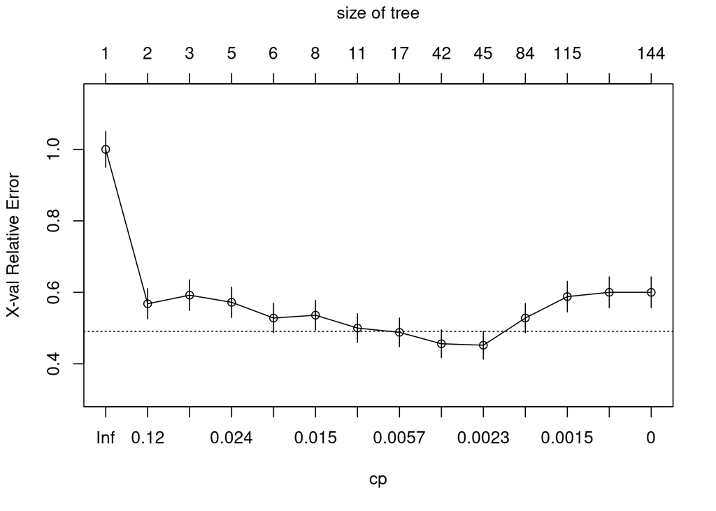

```r
plotcp(arvore)
```

```r
cp_min <- poda[which.min(poda[,'xerror']),'CP']
cp_min
```

```
## [1] 0.002
```

Dado que temos o menor CP recosntruímos a árvore:

```r
set.seed(123)
arvore_poda <- rpart::rpart(Survived ~ Pclass + Sex + Age + SibSp + Parch + Fare + Embarked,
                            data=treino,
                            method='class',
                            xval=0,
                            control = rpart.control(cp = cp_min,
                                                    minsplit = 1,
                                                    maxdepth = 30)
)
```

predição:

```r
library(caret)
previsto = stats::predict(arvore_poda, teste)

previsto = as.data.frame(previsto)
teste = cbind(teste,previsto)

previsto$SurvivedPredicted = "N"
previsto[previsto[,2] > 0.5,]$SurvivedPredicted = "Y"

teste = cbind(teste,SurvivedPredicted = previsto$SurvivedPredicted)
teste$SurvivedPredicted = as.factor(teste$SurvivedPredicted)
teste$SurvivedPredicted = relevel(teste$SurvivedPredicted , ref="N")

confusionMatrix(teste$SurvivedPredicted, teste$Survived, positive="N")
```

```
## Confusion Matrix and Statistics
##
##           Reference
## Prediction   N   Y
##          N 113  27
##          Y  17  65
##
##                Accuracy : 0.8018
##                  95% CI : (0.7432, 0.8521)
##     No Information Rate : 0.5856
##     P-Value [Acc > NIR] : 6.46e-12
##
##                   Kappa : 0.585
##
##  Mcnemar's Test P-Value : 0.1748
##
##             Sensitivity : 0.8692
##             Specificity : 0.7065
##          Pos Pred Value : 0.8071
##          Neg Pred Value : 0.7927
##              Prevalence : 0.5856
##          Detection Rate : 0.5090
##    Detection Prevalence : 0.6306
##       Balanced Accuracy : 0.7879
##
##        'Positive' Class : N
##
```

área ROC:

ROC:

```r
library(caret)
rocdata = data.frame(obs=teste$Survived,
                     pred=teste$SurvivedPredicted,
                     Y = teste$Y,
                     N = teste$N)

twoClassSummary(rocdata, lev=levels(rocdata$obs))
```

```
##       ROC      Sens      Spec
## 0.7736622 0.8692308 0.7065217
```

Curva ROC:

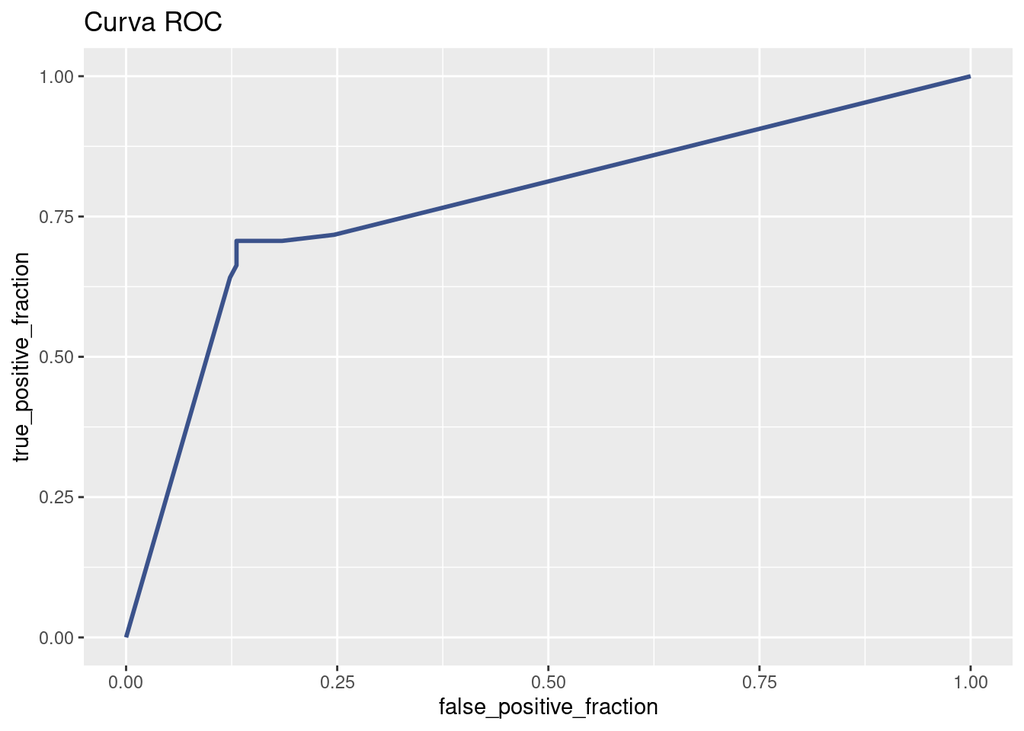

```r
library(plotROC)
ggplot(rocdata, aes(d = obs, m = Y, colour='a')) +
  plotROC::geom_roc(n.cuts = 0) +
  scale_color_viridis_d(direction = -1, begin=0, end=.25) +
  theme(legend.position = "none") +
  ggtitle("Curva ROC")
```